# Basic History

SARA शिक्षा ⋅ Free ⋅ Online ⋅ Open to All

Dr. Ajay Kumar Koli

August 26, 2026

## Welcome

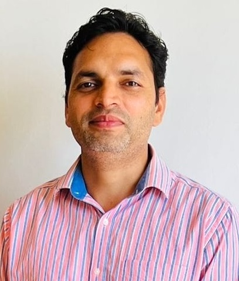

### **Dr. Ajay Koli** $\cdot$

Founder & Director · SARA

[figure not shown]

[figure not shown]

Title slide background image source: [krakograff](https://unsplash.com/photos/a-man-walking-down-a-street-next-to-a-wall-_ckTES3KFS4) on unsplash

# SARA Intro

[figure not shown]

#### Savitribai Phule (1831-1897) 🪷🙏🏽🪷

[figure not shown]

[figure not shown]

#### Ramabai Ambedkar (1898-1935) 🪷🙏🏽🪷

**Savitribai Ramabai (SARA) Institute of Data Science, Sonipat**

## About SARA

> Education for everyone
- Est. April 2023
- Free<sup>1</sup>, open-source and inclusive education
[^1]: Students only pay for their food and accommodation.

## SARA Data Schools

> Non-profit events $\cdot$ Offline $\cdot$ Sonipat (HR)
1. SARA Summer School “R for Researchers”
2. SARA Winter School “Statistics using R”
3. SARA March Bootcamp “Publish using Quarto”

## Bridge Courses

> Free $\cdot$ Online $\cdot$ Open to all
- Live on [SARA YouTube Channel](https://www.youtube.com/@SARADataScience)
- For first-generation parents & students.
- Essential subjects

## Social Media

> WhatsApp Channel `+840`

## Donate to SARA

- Account Name: SARA EDUCATION TRUST
- Account Number: `42920911856`
- Bank Name: STATE BANK OF INDIA
- IFSC Code: `SBIN0000721`

## SARA Library

> 40 Books for Bridge Course Level 1

Link: https://sara-edu.netlify.app/book-club/books-donation/sara_book_donations

## Contact SARA

**Address:**  
SARA Institute  
Dr. Ambedkar Bhavan  
Near Dayanand Hospital  
Kakroi Road, Sonipat  
Haryana - 131001, India  
Google Map Link: https://maps.app.goo.gl/d9S6a3pEFNXhnJGN6

**Phone:** +91 925 315 2024

**Email:** sara.institute.info@gmail.com

**Website:** https://sara-edu.netlify.app/

# Basic History

## About Author

> Yuval Noah Harari
- PhD from the University of Oxford
- His books sold 55 million copies in 65 languages

# The Timeline of History

## The Timeline of History

> 13.8 billion years ago

Matter and energy appear. Beginning of physics. Formation of atoms and molecules. Beginning of chemistry.

## The Timeline of History

> 4.5 billion years ago

Formation of planet Earth.

## The Timeline of History

> 3.8 billion years ago

Emergence of organisms. Beginning of biology.

## The Timeline of History

> 6 million years ago

Last common grandmother of humans and chimpanzees.

## The Timeline of History

> 2.5 million years ago

Humans evolve in Africa. Ue of stone tools.

## The Timeline of History

> 2 million years ago

Humans spread from Africa to Eurasia. Evolution of different human species.

## The Timeline of History

> 4,00,000 years ago

Neanderthals evolve in Europe and the Middle East. Regular use of fire.

> 3,00,000

*Homo sapiens* evolves in Africa

## Neanderthals “cousin” of Homo sapiens

[figure not shown]

Source: Screenshot of video from [Britannica Digital Studios](https://www.britannica.com/topic/Neanderthal)

## The Timeline of History

> 70,000 years ago

The Cognitive Revolution. Emergence of storytelling. Beginning of history. Sapiens spread out of Africa.

## The Timeline of History

> 50,000 years ago

Sapiens settle across Australia. Extinction of Australian megafauna.

[figure not shown]

Image source: [The Guardian](https://www.theguardian.com/science/2020/may/19/humans-australia-megafauna-to-extinction-climate-queensland)

## The Timeline of History

> 30,000 years ago

Extinction of Neanderthals. *Homo sapiens* the only surviving human species.

> 15,000 years ago

Sapiens spread across Americas. Extinction of American megafauna.

## The Timeline of History

> 12,000 years ago

The Agricultural Revolution. Domestication of plants and animals. Permanent settlements.

## The Timeline of History

> 5,000 years ago

First kingdoms, script and money. Polytheistic religions.

## The Timeline of History

> 4250 years ago

First empire - the Akkadian<sup>1</sup> Empire of Sargon<sup>2</sup>

## The Timeline of History

> 2500 years ago
- Invention of coins - a universal money.
- The Persian Empire - a universal political order.
- Buddhism in India - a universal teaching.

## The Timeline of History

> 2000 years ago

Han Empire in China. Roman Empire in the Mediterranean. Christianity.

> 1400 year ago

Islam

## The Timeline of History

> 500 years ago
- The Scientific Revolution
- Humankind admits its ignorance and begins to acquire unprecedented power.
- Europeans begin to conquer America and the oceans.
- The entire planet becomes a single historical arena.
- The rise of capitalism.

## The Timeline of History

> 200 years ago
- The Industrial Revolution.
- Family and community are replaced by state and market.
- Massive extinction of plants and animals.

## The Present

- Humans transcend the boundaries of planet Earth.
- Nuclear weapons threaten the survival of humankind.
- Organisms are increasingly shaped by intelligent design rather than natural selection.

# Part One

> The COGNITIVE REVOLUTION